# The ACNH Museum: Should you take Marina?

Created by Julie aka @corbeau0

Last updated April 08 2021

# Introduction

Let’s say you went on a villager hunt and you **did not stop** until you found Marina. You kept at it, ticket after ticket, until you found the game’s one and only pink octopus. And then you did that 5000 times. 5000 hunts, solely looking for Marina.

After 5000 hunts looking for Marina, you then used the same process to look for Raymond. And then, again, for Fauna. 15000 villager hunts, for a total of who-knows how many tickets.

In this document, I will simulate 15000 villager hunts to demonstrate that, yes, it is really that easy to find Marina.

[figure not shown]

It’s that easy.

[I used code from this coin flip simulator,](https://stats.stackexchange.com/questions/136806/expected-number-of-tosses-till-first-head-comes-up) but instead of using a 50/50 chance of getting heads or tails, I substituted the probability of finding Marina, Raymond, or Fauna.

The probability of finding a villager is 1/35 (because there are 35 species) multiplied by one over the number of individual villagers in that species.

```r
(1/35)*(1/3) # Marina's probability
```

```
## [1] 0.00952381
```

```r
(1/35)*(1/23) # Raymond's probability
```

```
## [1] 0.001242236
```

```r
(1/35)*(1/10) # Fauna's probability
```

```
## [1] 0.002857143
```

This is assuming that, if you’re looking for Raymond, you don’t have any cats on your island, or that you don’t have all of 1 species on your island (e.g., if you’re looking for Marina, you don’t have all 8 goats currently on your island). I will talk more about that later in another document.

# Simulate 5000 hunts for Marina

```r
set.seed(12345)
     # This is a seed number, it helps so that "randomness" can replicated later on
     # We only need to do this once
```

```r
p <- (1/35)*(1/3)                     # The probability of finding Marina

     reps <- 5000                          # Total number of simulations

     Marina <- 0                           # Setting up an empty vector to add output to.

     for (i in 1:reps) {
       find_villager <- 0                  # Set the variable 'find_villager' to 0 with every loop.
       counter <- 0                        # Same for local variable 'counter'
       while (find_villager == 0) {
         find_villager <- find_villager + rbinom(1, 1, p) # Visit a mystery island and add to 'find_villager'
         counter <- counter + 1            # Add 1 to 'counter'
       }
       Marina[i] <- counter                # Put number in counter after finding Marina.
     }

     mean(Marina) # What's the average number of islands it took to find Marina?
```

```
## [1] 103.7482
```

```r
df <- data.frame(Marina) # Save Marina's villager hunts to a dataset
     df$rownumber <- 1:nrow(df)
```

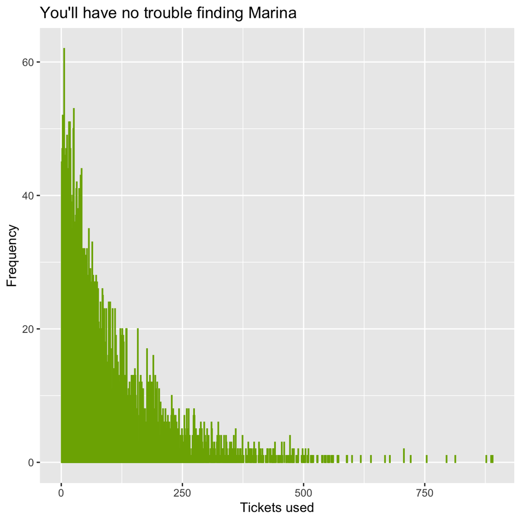

```r
ggplot(df, aes(x=Marina)) +
       geom_bar(fill = "#7CAE00", color = "#7CAE00") +
       xlab("Tickets used") +
       ylab("Frequency") +
       ggtitle("You'll have no trouble finding Marina")
```

# Simulate 5000 hunts for Raymond

```r
p <- (1/35)*(1/23)                    # The probability of finding Raymond

     reps <- 5000                          # Total number of simulations

     Raymond <- 0                          # Setting up an empty vector to add output to

     for (i in 1:reps) {
       find_villager <- 0                  # Set the variable 'find_villager' to 0 with every loop
       counter <- 0                        # Same for local variable 'counter'
       while (find_villager == 0) {
         find_villager <- find_villager + rbinom(1, 1, p) # Visit a mystery island and add to 'find_villager'
         counter <- counter + 1            # Add 1 to 'counter'
       }
       Raymond[i] <- counter               # Put number in counter after getting Raymond.
     }

     mean(Raymond) # What's the average number of islands it took to find Raymond?
```

```
## [1] 801.9746
```

```r
df2 <- data.frame(Raymond) # Save Raymond's villager hunts to a dataset
     df2$rownumber <- 1:nrow(df2)
```

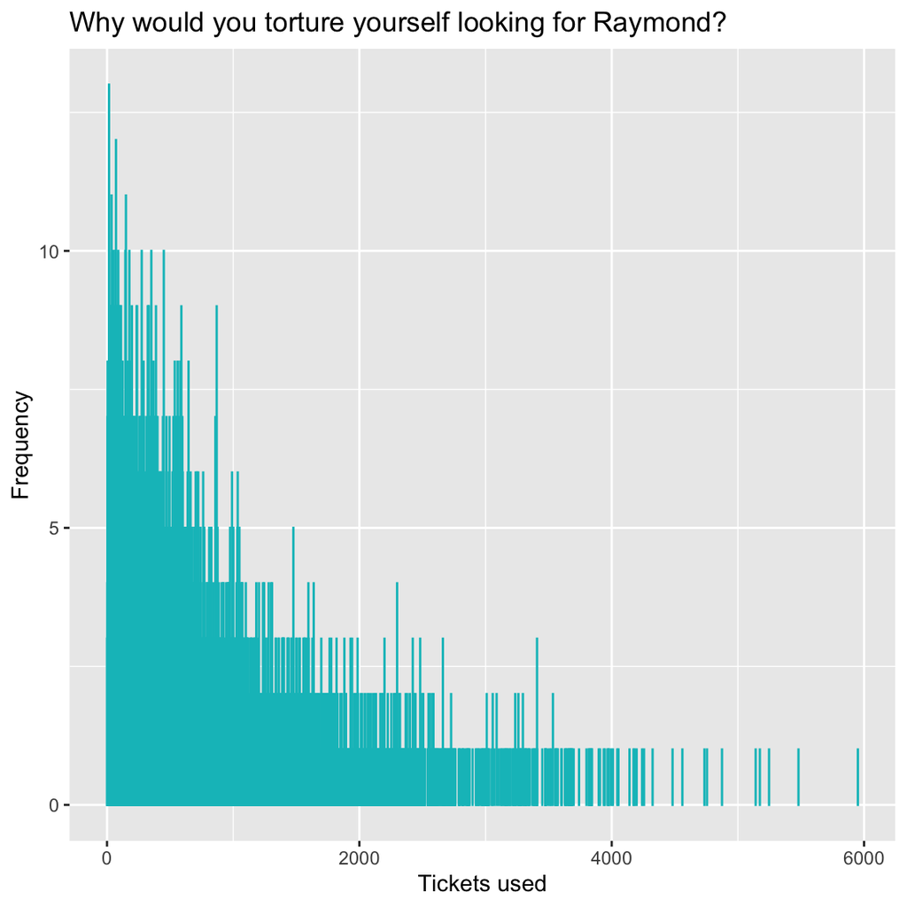

```r
ggplot(df2, aes(x=Raymond)) +
       geom_bar(fill = "#00BFC4", color = "#00BFC4") +
       xlab("Tickets used") +
       ylab("Frequency") +
       ggtitle("Why would you torture yourself looking for Raymond?")
```

# Simulate 5000 hunts for Fauna

```r
p <- (1/35)*(1/10)                     # The probability of finding Fauna

     reps <- 5000                          # Total number of simulations

     Fauna <- 0                            # Setting up an empty vector to add output to.

     for (i in 1:reps) {
       find_villager <- 0                  # Set the variable 'find_villager' to 0 with every loop.
       counter <- 0                        # Same for local variable 'counter'
       while (find_villager == 0) {
         find_villager <- find_villager + rbinom(1, 1, p) # Visit a mystery island and add to 'find_villager'
         counter <- counter + 1            # Add 1 to 'counter'
       }
       Fauna[i] <- counter                 # Put number in counter after getting Fauna.
     }

     mean(Fauna) # What's the average number of islands it took to find Fauna?
```

```
## [1] 353.5544
```

```r
df3 <- data.frame(Fauna) # Save Fauna's villager hunts to a dataset
     df3$rownumber <- 1:nrow(df3)
```

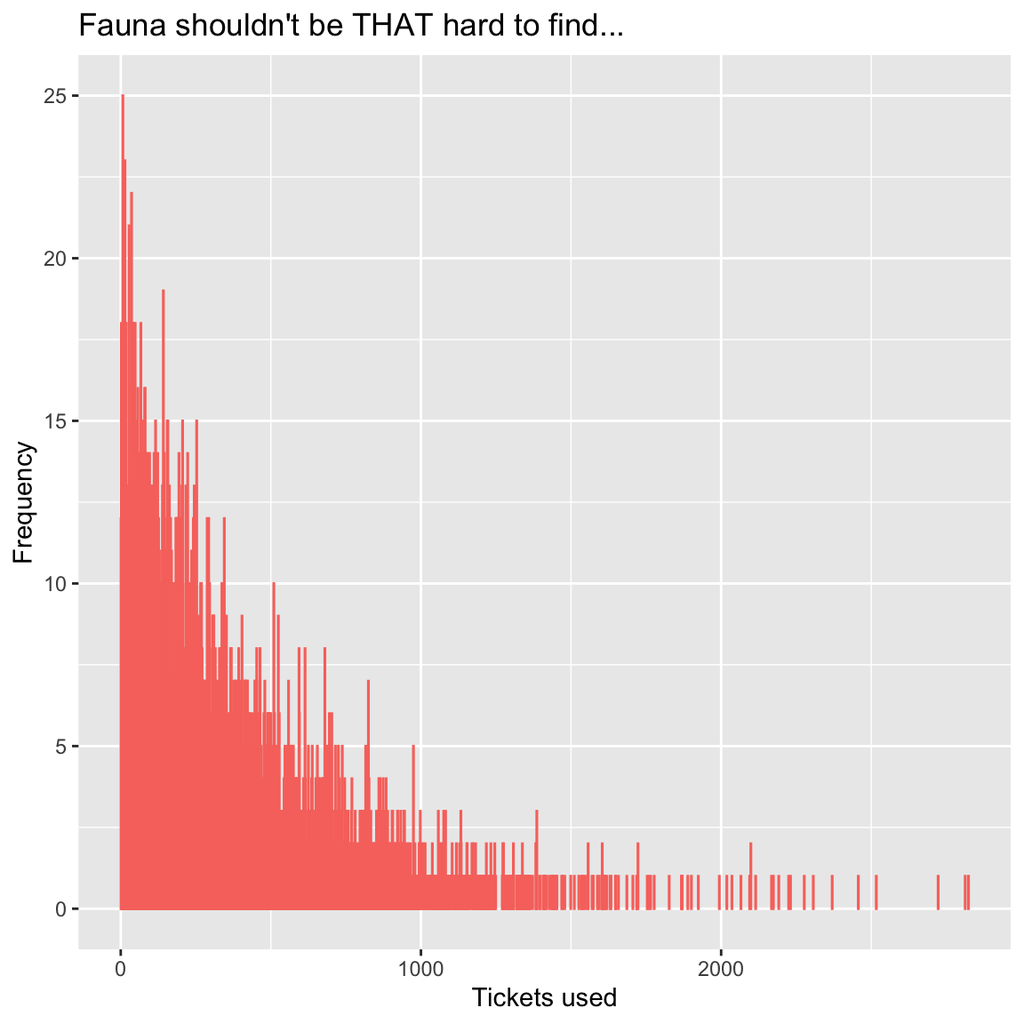

```r
ggplot(df3, aes(x=Fauna)) +
       geom_bar(fill = "#F8766D", color = "#F8766D") +
       xlab("Tickets used") +
       ylab("Frequency") +
       ggtitle("Fauna shouldn't be THAT hard to find...")
```

# Visualization and Conclusion

Now that we’ve conducted 15000 villager hunts, let’s see what it looks like.

```r
# Combine the datasets of Marina's, Raymond's, and Fauna's hunts together
     dfmerge <- merge(df, df2, by = "rownumber")
     dfmerge <- merge(dfmerge, df3, by = "rownumber")

     # 'Melt' the dataset so it's long, not wide
     melt <- melt(dfmerge, id.vars = "rownumber")

     head(dfmerge) # This is the wide dataset
```

```
##   rownumber Marina Raymond Fauna
     ## 1         1    167     459   397
     ## 2         2    102      73   640
     ## 3         3      5     564  1273
     ## 4         4     79     511   544
     ## 5         5    140     771    28
     ## 6         6    516    1007   383
```

```r
head(melt) # This is the long dataset, which we'll use
```

```
##   rownumber variable value
     ## 1         1   Marina   167
     ## 2         2   Marina   102
     ## 3         3   Marina     5
     ## 4         4   Marina    79
     ## 5         5   Marina   140
     ## 6         6   Marina   516
```

```r
# Rename variables so it's cleaner
     melt$variable <- as.character(melt$variable)
     names(melt)[names(melt) == "value"] <- "Tickets_Used"
     names(melt)[names(melt) == "variable"] <- "Villager"

     # Do some magic
     df_ani <- melt %>%
       split(.$rownumber) %>%
       accumulate(~ bind_rows(.x, .y)) %>%
       bind_rows(.id = "frame") %>%
       mutate(frame = as.integer(frame))

     # Make a boring, stationary graph
     p_anim <- ggplot(data = df_ani, aes(x = Tickets_Used, fill=Villager)) +
       geom_histogram(binwidth = 100, alpha = 0.5, position="identity") +
       ggtitle("A simulation of 5000 villager hunts") +
       ylab("Frequency") +
       xlab("Number of NMTs used") +
       labs(subtitle = "Villager hunting for Fauna vs. Marina vs. Raymond")
       scale_x_continuous(breaks = seq(0, max(df_ani$Tickets_Used), by = 500))
```

```
## <ScaleContinuousPosition>
     ##  Range:
     ##  Limits:    0 --    1
```

[figure not shown]

```r
# Make the graph animated!
     anim <- p_anim +
       transition_manual(frame) +
       ease_aes("linear") +
       enter_fade() +
       exit_fade()

     # Print the animated graph so you can see it on this page
     anim
```

In conclusion, it’s way easier to find Marina over Raymond. If you’re going to go on a long villager hunt, why not try to at least look to a rarer villager than take the most commonly appearing villager in the game? Marina’s pretty cute, though - at least it’s her and not Barold!